# Matching and Inverse Probability Weighting

Lindsey Dorson

# Program overview

The metropolitan Atlanta area is interested in helping residents become more environmentally conscious, reduce their water consumption, and save money on their monthly water bills. To do this, Fulton, DeKalb, Gwinnett, Cobb, and Clayton counties have jointly initiated a new program that provides free rain barrels to families who request them. These barrels collect rain water, and the reclaimed water can be used for non-potable purposes (like watering lawns and gardens). Officials hope that families that use the barrels will rely more on rain water and will subsequently use fewer county water resources, thus saving both the families and the counties money.

Being evaluation-minded, the counties hired an evaluator (you!) before rolling out their program. You convinced them to fund and run a randomized controlled trial (RCT) during 2018, and the counties rolled out the program city-wide in 2019. You have two datasets: `barrels_rct.csv` with data from the RCT, and `barrels_obs.csv` with observational data from self-selected participants.

These datasets contain the following variables:

- `id`: A unique ID number for each household
- `water_bill`: The family’s average monthly water bill, in dollars
- `barrel`: An indicator variable showing if the family participated in the program
- `barrel_num`: A 0/1 numeric version of `barrel`
- `yard_size`: The size of the family’s yard, in square feet
- `home_garden`: An indicator variable showing if the family has a home garden
- `home_garden_num`: A 0/1 numeric version of `home_garden`
- `attitude_env`: The family’s self-reported attitude toward the environment, on a scale of 1-10 (10 meaning highest regard for the environment)
- `temperature`: The average outside temperature (these get wildly unrealistic for the Atlanta area; just go with it)

# Your goal

Your task in this problem set is to analyze these two datasets to find the causal effect (or average treatment effect (ATE)) of this hypothetical program.

As a reference, Figure 1 shows the DAG for the program:

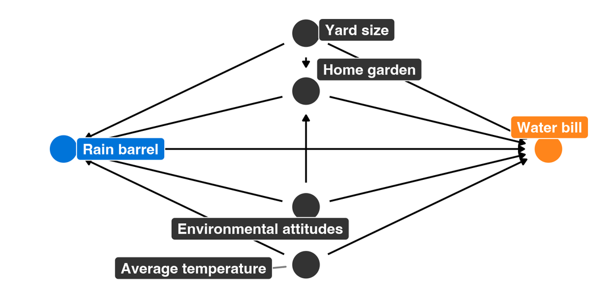

Rain barrel program DAG

```r
library(tidyverse)
library(broom)
library(patchwork)
library(MatchIt)
library(modelsummary)
library(kableExtra)

barrels_rct <- read_csv("data/barrels_rct.csv") %>%
  # This makes it so "No barrel" is the reference category
  mutate(barrel = fct_relevel(barrel, "No barrel"))

barrels_obs <- read_csv("data/barrels_observational.csv") %>%
  # This makes it so "No barrel" is the reference category
  mutate(barrel = fct_relevel(barrel, "No barrel"))
```

# 1. Finding causation from a randomized controlled trial

## Modified DAG

You remember from PMAP 8521 that when running an RCT, you can draw the DAG for the program like this (Figure 2). **Why?**

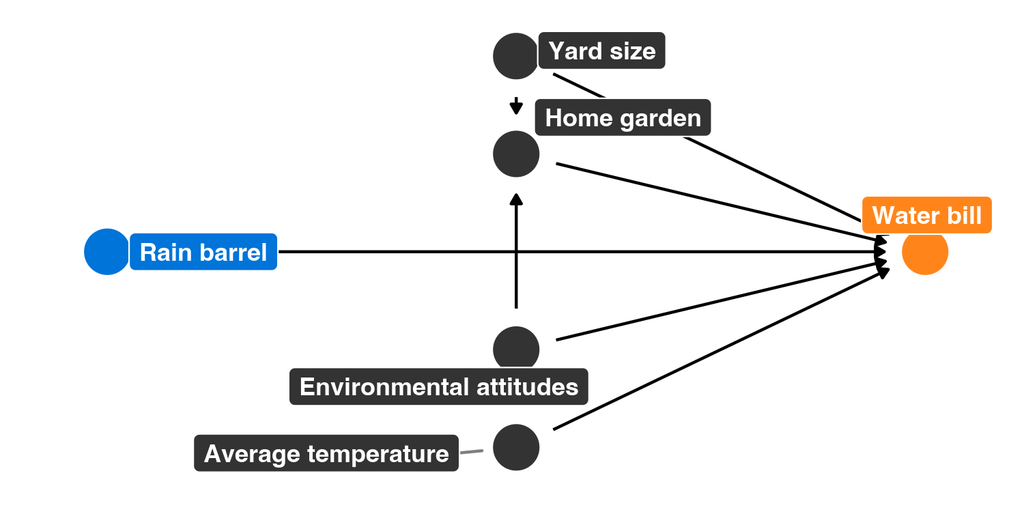

Randomized experiments get rid of confounding variables because there should be no difference in the people selected into treatment and control groups(equal distribution of characteristics).

## Check balance

**Discuss the sample size for the RCT data and how many people were assigned to treatment/control. Are you happy with this randomization?**

```r
barrels_rct%>%
  count(barrel)%>%
  mutate(prop =n /sum(n))
```

```
## # A tibble: 2 × 3
##   barrel        n  prop
##   <fct>     <int> <dbl>
## 1 No barrel   221 0.448
## 2 Barrel      272 0.552
```

```r
table(barrels_rct$barrel) %>% prop.test() %>% tidy()
```

```
## # A tibble: 1 × 8
##   estimate statistic p.value parameter conf.low conf.high method         alter…¹
##      <dbl>     <dbl>   <dbl>     <int>    <dbl>     <dbl> <chr>          <chr>
## 1    0.448      5.07  0.0243         1    0.404     0.493 1-sample prop… two.si…
## # … with abbreviated variable name ¹alternative
```

Based on the results, there is statistical difference between the two groups.

**Check the balance of the main pre-treatment characteristics. Are you happy with the balance?**

```r
barrels_rct %>%
  group_by(barrel) %>%
  summarize(yard_avg = mean(yard_size),
            home_avg = mean(home_garden_num),
            attitude_avg = mean(attitude_env),
            temp_avg = mean(temperature))
```

```
## # A tibble: 2 × 5
##   barrel    yard_avg home_avg attitude_avg temp_avg
##   <fct>        <dbl>    <dbl>        <dbl>    <dbl>
## 1 No barrel   21309.    0.267         5.52     69.6
## 2 Barrel      20357.    0.206         5.42     69.8
```

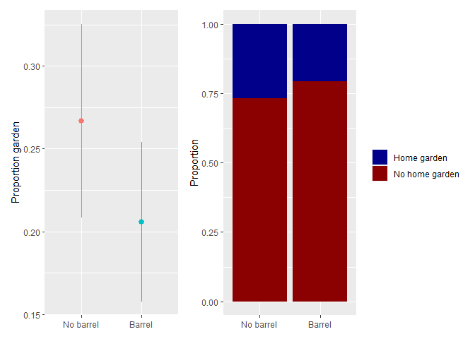

```r
plot_diff_garden <- ggplot(barrels_rct, aes(x = barrel, y = home_garden_num, color = barrel)) +
  stat_summary(geom = "pointrange", fun.data = "mean_se", fun.args = list(mult = 1.96)) +
  guides(color = "none") +
  labs(x = NULL, y = "Proportion garden")

plot_prop_garden <- ggplot(barrels_rct, aes(x = barrel, fill = home_garden)) +
geom_bar(position = "fill") +
labs(x = NULL, y = "Proportion", fill = NULL) +
scale_fill_manual(values = c("darkblue", "darkred"))

plot_diff_garden + plot_prop_garden
```

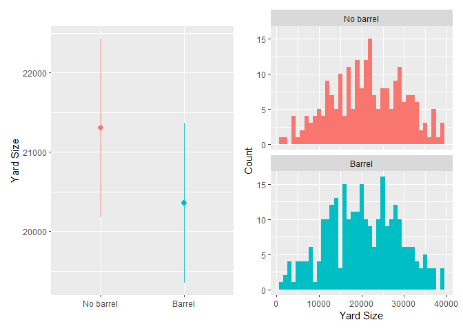

```r
plot_diff_yard <- ggplot(barrels_rct, aes(x = barrel, y = yard_size, color = barrel)) +
  stat_summary(geom = "pointrange", fun.data = "mean_se", fun.args = list(mult = 1.96)) +
  guides(color = "none") +
  labs(x = NULL, y = "Yard Size")


plot_hist_yard <- ggplot(barrels_rct, aes(x = yard_size, fill = barrel)) +
  geom_histogram(binwidth = 1000) +
  guides(fill = "none") +
  labs(x = "Yard Size", y = "Count") +
  facet_wrap(vars(barrel), ncol = 1)

plot_diff_yard + plot_hist_yard
```

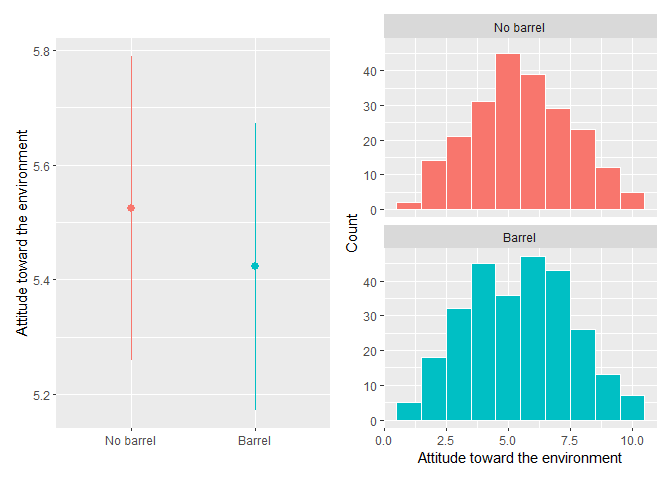

```r
plot_diff_env <- ggplot(barrels_rct, aes(x = barrel, y = attitude_env, color = barrel)) +
  stat_summary(geom = "pointrange", fun.data = "mean_se", fun.args = list(mult = 1.96)) +
  guides(color = "none") +
  labs(x = NULL, y = "Attitude toward the environment")

plot_hist_env <- ggplot(barrels_rct, aes(x = attitude_env, fill = barrel)) +
  geom_histogram(binwidth = 1, color = "white") +
  guides(fill = "none") +
  labs(x = "Attitude toward the environment", y = "Count") +
  facet_wrap(vars(barrel), ncol = 1)

plot_diff_env + plot_hist_env
```

```r
##check temperature without graph
t.test(temperature ~ barrel, data = barrels_rct) %>% tidy()
```

```
## # A tibble: 1 × 10
##   estim…¹ estim…² estim…³ stati…⁴ p.value param…⁵ conf.…⁶ conf.…⁷ method alter…⁸
##     <dbl>   <dbl>   <dbl>   <dbl>   <dbl>   <dbl>   <dbl>   <dbl> <chr>  <chr>
## 1  -0.174    69.6    69.8  -0.383   0.702    486.   -1.07   0.719 Welch… two.si…
## # … with abbreviated variable names ¹estimate, ²estimate1, ³estimate2,
## #   ⁴statistic, ⁵parameter, ⁶conf.low, ⁷conf.high, ⁸alternative
```

All variables do not appear to have any huge variations between group types.

## Estimate difference

**What is the effect of the program on participants’ water bills? How credible is this result?**

```r
model_rct <- lm(water_bill~barrel_num, data = barrels_rct)
tidy(model_rct)
```

```
## # A tibble: 2 × 5
##   term        estimate std.error statistic  p.value
##   <chr>          <dbl>     <dbl>     <dbl>    <dbl>
## 1 (Intercept)    228.       2.04     112.  0
## 2 barrel_num     -40.6      2.74     -14.8 3.55e-41
```

The rain barrel program caused a statistically significant decrease of $40.57 in water bills, on average. These results can be given a causal interpretation due to the randomized experiment design.

# 2. Finding causation from observational data

## Naive difference in means

**As a baseline measure, calculate the average difference in water bills for those in the program and those not in the program using the observational data. How much of an effect is there? How credible is this result? Why?**

```r
naive<- lm(water_bill ~ barrel_num, data = barrels_obs)
tidy(naive)
```

```
## # A tibble: 2 × 5
##   term        estimate std.error statistic  p.value
##   <chr>          <dbl>     <dbl>     <dbl>    <dbl>
## 1 (Intercept)    225.       1.07     211.  0
## 2 barrel_num     -29.9      1.67     -17.8 1.61e-63
```

Those who used barrels saved $29.86 on their water bills, on average. However, a causal affect cannot be attributed to this estimate since there are confounding variables that need to be controlled and there is self selection.

## Adjustment with Mahalanobis nearest-neighbor matching

**Use matching to make the proper adjustments and close the backdoor effects from the four main confounders: `yard_size`, `home_garden`, `attitude_env`, and `temperature`**

```r
matched <- matchit(barrel_num ~ yard_size + home_garden_num + attitude_env + temperature,
                        data = barrels_obs,
                        method = "nearest",
                        distance = "mahalanobis",
                        replace = TRUE)
summary(matched)
```

```
##
## Call:
## matchit(formula = barrel_num ~ yard_size + home_garden_num +
##     attitude_env + temperature, data = barrels_obs, method = "nearest",
##     distance = "mahalanobis", replace = TRUE)
##
## Summary of Balance for All Data:
##                 Means Treated Means Control Std. Mean Diff. Var. Ratio
## yard_size          21173.5505    20166.7283          0.1192     1.0373
## home_garden_num        0.2574        0.1848          0.1661          .
## attitude_env           5.5426        5.1196          0.2078     1.0604
## temperature           71.7804       68.6484          0.6243     1.1025
##                 eCDF Mean eCDF Max
## yard_size          0.0368   0.0706
## home_garden_num    0.0726   0.0726
## attitude_env       0.0423   0.1058
## temperature        0.1284   0.2692
##
##
## Summary of Balance for Matched Data:
##                 Means Treated Means Control Std. Mean Diff. Var. Ratio
## yard_size          21173.5505    21082.9505          0.0107     1.0600
## home_garden_num        0.2574        0.2574          0.0000          .
## attitude_env           5.5426        5.5347          0.0039     1.0316
## temperature           71.7804       71.5305          0.0498     1.1064
##                 eCDF Mean eCDF Max Std. Pair Dist.
## yard_size          0.0098   0.0337          0.1454
## home_garden_num    0.0000   0.0000          0.0000
## attitude_env       0.0059   0.0178          0.0486
## temperature        0.0114   0.0475          0.1692
##
## Sample Sizes:
##               Control Treated
## All            736.       505
## Matched (ESS)  208.52     505
## Matched        300.       505
## Unmatched      436.         0
## Discarded        0.         0
```

```r
matched_data <-match.data(matched)

model_matched_wts<-lm(water_bill~barrel_num,
                  data = matched_data,
                  weights = weights)

tidy(model_matched_wts)
```

```
## # A tibble: 2 × 5
##   term        estimate std.error statistic  p.value
##   <chr>          <dbl>     <dbl>     <dbl>    <dbl>
## 1 (Intercept)    234.       1.68     140.  0
## 2 barrel_num     -39.4      2.12     -18.6 1.46e-64
```

## Adjustment with inverse probability weighting

**Use inverse probability weighting to make the proper adjustments and close the backdoor effects from the four main confounders: `yard_size`, `home_garden`, `attitude_env`, and `temperature`**

```r
inverse <- glm(barrel_num ~ yard_size + home_garden_num + attitude_env + temperature,
                 data = barrels_obs,
                 family = binomial(link = "logit"))
```

```r
probabilities <- augment_columns(inverse,
                                     barrels_obs,
                                     type.predict = "response") %>%
  rename(propensity = .fitted)

probabilities %>%
  select(id, barrel_num, yard_size, home_garden_num, attitude_env, temperature, propensity) %>%
  head()
```

```
## # A tibble: 6 × 7
##      id barrel_num yard_size home_garden_num attitude_env temperature propensity
##   <dbl>      <dbl>     <dbl>           <dbl>        <dbl>       <dbl>      <dbl>
## 1     1          1     25811               0            3        81.1      0.705
## 2     2          0     39479               1            7        65.1      0.354
## 3     3          1     13297               0            7        75.9      0.629
## 4     4          0     28259               0            2        70.6      0.339
## 5     5          1     21479               0            5        66.7      0.292
## 6     6          1     28906               1            8        75.3      0.686
```

```r
ipw <- probabilities %>%
  mutate(ipw = (barrel_num / propensity) + ((1 - barrel_num) / (1 - propensity)))

ipw %>%
  select(id, barrel_num, yard_size, home_garden_num, attitude_env, temperature, propensity,ipw) %>%
  head()
```

```
## # A tibble: 6 × 8
##      id barrel_num yard_size home_garden_num attitude_env temper…¹ prope…²   ipw
##   <dbl>      <dbl>     <dbl>           <dbl>        <dbl>    <dbl>   <dbl> <dbl>
## 1     1          1     25811               0            3     81.1   0.705  1.42
## 2     2          0     39479               1            7     65.1   0.354  1.55
## 3     3          1     13297               0            7     75.9   0.629  1.59
## 4     4          0     28259               0            2     70.6   0.339  1.51
## 5     5          1     21479               0            5     66.7   0.292  3.43
## 6     6          1     28906               1            8     75.3   0.686  1.46
## # … with abbreviated variable names ¹temperature, ²propensity
```

```r
model_ipw<- lm(water_bill ~ barrel_num,
                data = ipw,
                weights = ipw)
tidy(model_ipw)
```

```
## # A tibble: 2 × 5
##   term        estimate std.error statistic   p.value
##   <chr>          <dbl>     <dbl>     <dbl>     <dbl>
## 1 (Intercept)    228.       1.19     192.  0
## 2 barrel_num     -39.1      1.67     -23.4 1.68e-100
```

```r
summary(ipw$ipw)
```

```
##    Min. 1st Qu.  Median    Mean 3rd Qu.    Max.
##   1.064   1.436   1.706   2.010   2.222  20.547
```

```r
sum(ipw$ipw >8)
```

```
## [1] 3
```

There are some very high IPW values that could throw off estimation. Try truncated model.

```r
ipw<-ipw%>%
  mutate(ipw_truncated =ifelse(ipw > 8,8,ipw))

model_ipw_trunc <- lm(water_bill ~ barrel_num,
                data = ipw,
                weights = ipw_truncated)

tidy(model_ipw_trunc)
```

```
## # A tibble: 2 × 5
##   term        estimate std.error statistic  p.value
##   <chr>          <dbl>     <dbl>     <dbl>    <dbl>
## 1 (Intercept)    228.       1.18     193.  0
## 2 barrel_num     -38.5      1.66     -23.1 1.64e-98
```

After using inverse probability weighting, the observational ATE for the rain barrel program is $38.45, which is again much closer to $40 than the naive estimate.

# 3. Comparing results

You just calculated a bunch of ATEs using experimental and observational data. **Put them all in a single table here:**

```r
modelsummary(list("RCT"= model_rct,
                  "Naive" = naive,
                  "Matched + weights" = model_matched_wts,
                  "IPW" = model_ipw,
                  "IPW truncated at 8" = model_ipw_trunc))%>%
  kableExtra::row_spec(3, bold = TRUE, color = "white", background = "green") %>%
  kableExtra::kable_styling(latex_options = "hold_position")
```

|  | RCT | Naive | Matched + weights | IPW | IPW truncated at 8 |
| --- | --- | --- | --- | --- | --- |
| (Intercept) | 228.442 | 224.800 | 234.371 | 228.214 | 228.214 |
|  | (2.038) | (1.068) | (1.678) | (1.189) | (1.180) |
| barrel_num | -40.573 | -29.860 | -39.431 | -39.050 | -38.454 |
|  | (2.744) | (1.674) | (2.118) | (1.670) | (1.664) |
| Num.Obs. | 493 | 1241 | 805 | 1241 | 1241 |
| R2 | 0.308 | 0.204 | 0.301 | 0.306 | 0.301 |
| R2 Adj. | 0.307 | 0.204 | 0.301 | 0.306 | 0.301 |
| AIC | 4766.6 | 11881.0 | 7758.9 | 12016.2 | 12000.3 |
| BIC | 4779.2 | 11896.3 | 7772.9 | 12031.6 | 12015.7 |
| Log.Lik. | -2380.295 | -5937.482 | -3876.430 | -6005.090 | -5997.145 |
| F | 218.574 | 318.160 | 346.456 | 547.025 | 533.896 |
| RMSE | 30.24 | 28.95 | 29.13 | 29.30 | 29.25 |

**Which estimates do you believe? Why? Would observational ATEs be sufficient to prove program effect in this case? Why or why not? Should this program be rolled out throughout Georgia? Why or why not?**

The RCT data gave a causal estimate of -$40.57, so the matched weighting model was closest to that value. I believe the observational ATEs would be sufficient because there is minimal difference in the results and they all show a negative and significant relationship due to the program. Therefore, the program was effective in reducing the water bills for the families and the counties the program was ran in. The program should be rolled out throughout Georgia.